# Project - Report

George Surilas

April 7, 2018

## Introduction

The idea behind this project was to see if the happiness ranking of a country as given by the 2017 Gallup poll was reflected in the happiness of the major literary works from that country. I used three data sources to do this; Wikipedia, R-Gutenberg package, and the Gallup 2017 Happiness poll data.

First I decided to look at overall happiness trends throughout the world. Then I zeroed in on 5 countries in particular; Russia, Greece, France, USA and the UK and explored the happiness trends in those countries. The reason I chose these countries, is the R-Gutenberg package mainly contains Western authors. I would have been very interested to do a East vs West analysis of literary and happiness trends, but unfortunately the Gutenberg package doesn’t contain many Eastern authors.

## The Happiest Places

```
## # A tibble: 10 x 4
##    Happiness.Rank Country     Region                    Happiness.Score
##             <int> <chr>       <chr>                               <dbl>
##  1              1 Norway      Western Europe                       7.54
##  2              2 Denmark     Western Europe                       7.52
##  3              3 Iceland     Western Europe                       7.50
##  4              4 Switzerland Western Europe                       7.49
##  5              5 Finland     Western Europe                       7.47
##  6              6 Netherlands Western Europe                       7.38
##  7              7 Canada      North America                        7.32
##  8              8 New Zealand Australia and New Zealand            7.31
##  9              9 Sweden      Western Europe                       7.28
## 10             10 Australia   Australia and New Zealand            7.28
```

## The Unhappiest Places

```
## # A tibble: 10 x 4
##    Happiness.Rank Country                  Region          Happiness.Score
##             <int> <chr>                    <chr>                     <dbl>
##  1            146 Yemen                    Middle East an~            3.59
##  2            147 South Sudan              Sub-Saharan Af~            3.59
##  3            148 Liberia                  Sub-Saharan Af~            3.53
##  4            149 Guinea                   Sub-Saharan Af~            3.51
##  5            150 Togo                     Sub-Saharan Af~            3.49
##  6            151 Rwanda                   Sub-Saharan Af~            3.47
##  7            152 Syria                    Middle East an~            3.46
##  8            153 Tanzania                 Sub-Saharan Af~            3.35
##  9            154 Burundi                  Sub-Saharan Af~            2.90
## 10            155 Central African Republic <NA>                       2.69
```

Above we see that most of the high-ranking countries are either in Europe or Australia while the low-ranking countries are in Africa. The top countries and lowest ranked countries also differ in what variables they consider important to their happiness.

## Happiness Variable Contribution by Ranking

Here we see that the top 10 countries seem to have a consensus on what makes them happy. GDP and Family are both most important followed by Health, Freedom, Generosity and Government Corruption.

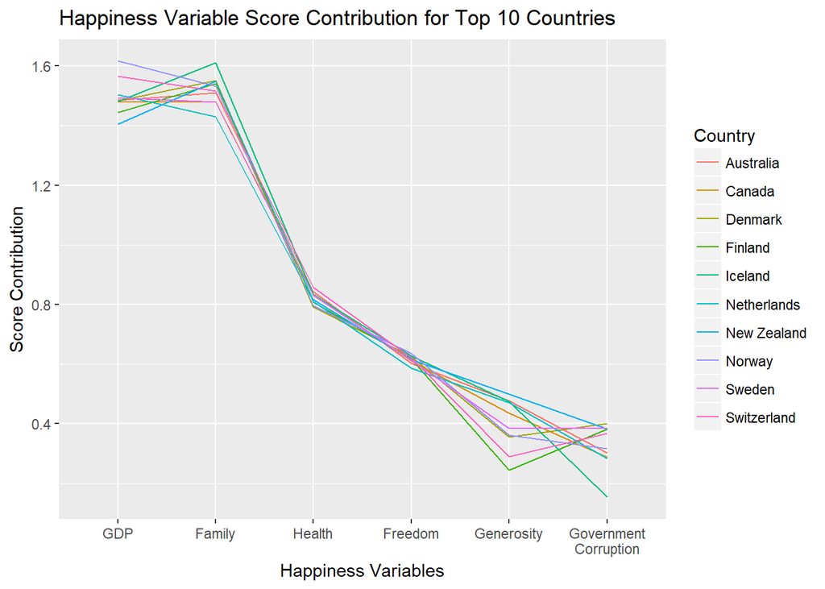

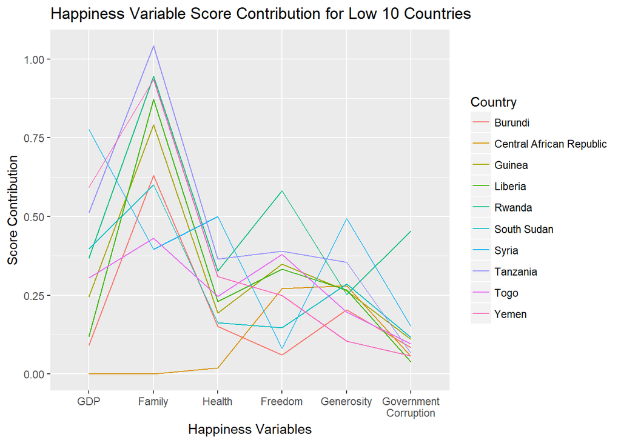

## Happiness by Region

The average happiness by world region is not too surprising. Overall, more developed regions seem to report happier citizens.

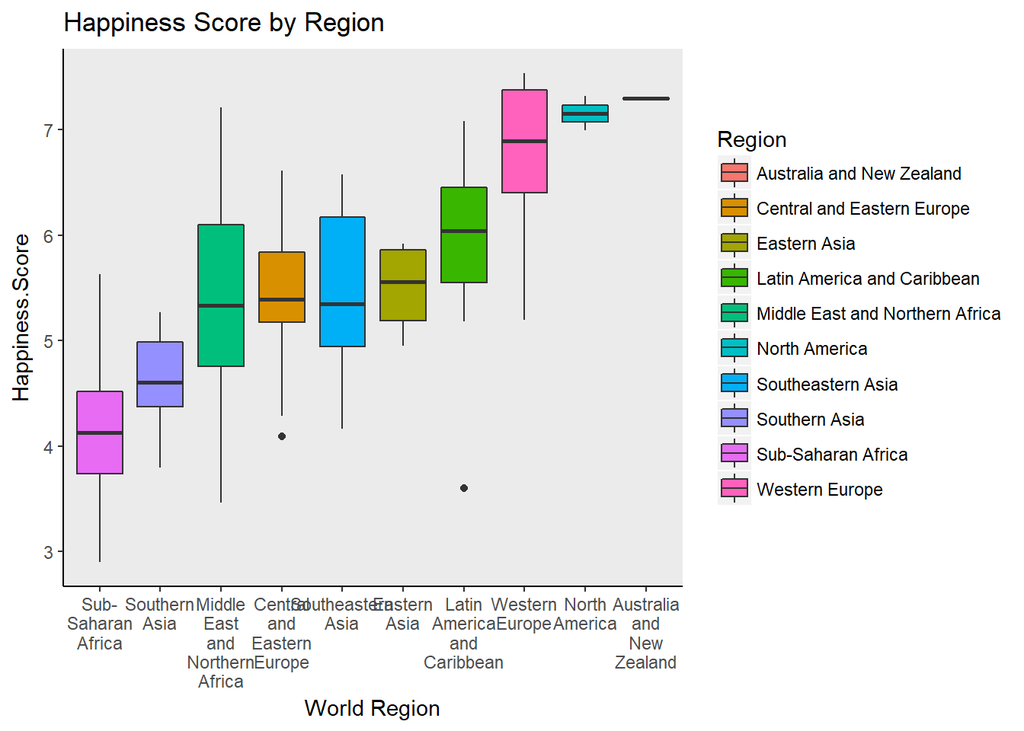

## Happiness Variables by World Region

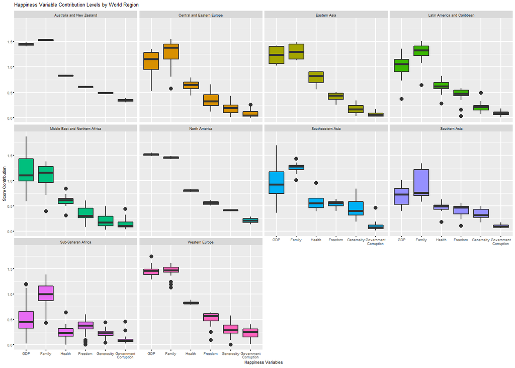

## 5 Countries Overview

The next part of the report focuses on the happiness and literary analysis of our 5 selected countries. First, we examine their happiness rankings to get a general picture of their overall happiness.

```
## # A tibble: 5 x 9
##   Happiness.Rank Country        Happiness.Score   GDP Family Health
##            <int> <chr>                    <dbl> <dbl>  <dbl>  <dbl>
## 1             14 United States             6.99  1.55   1.42  0.774
## 2             19 United Kingdom            6.71  1.44   1.50  0.805
## 3             31 France                    6.44  1.43   1.39  0.844
## 4             49 Russia                    5.96  1.28   1.47  0.547
## 5             87 Greece                    5.23  1.29   1.24  0.810
##   Freedom Generosity `Government Corruption`
##     <dbl>      <dbl>                   <dbl>
## 1  0.506      0.393                   0.136
## 2  0.508      0.493                   0.265
## 3  0.470      0.130                   0.173
## 4  0.374      0.0523                  0.0330
## 5  0.0957     0.                      0.0433
```

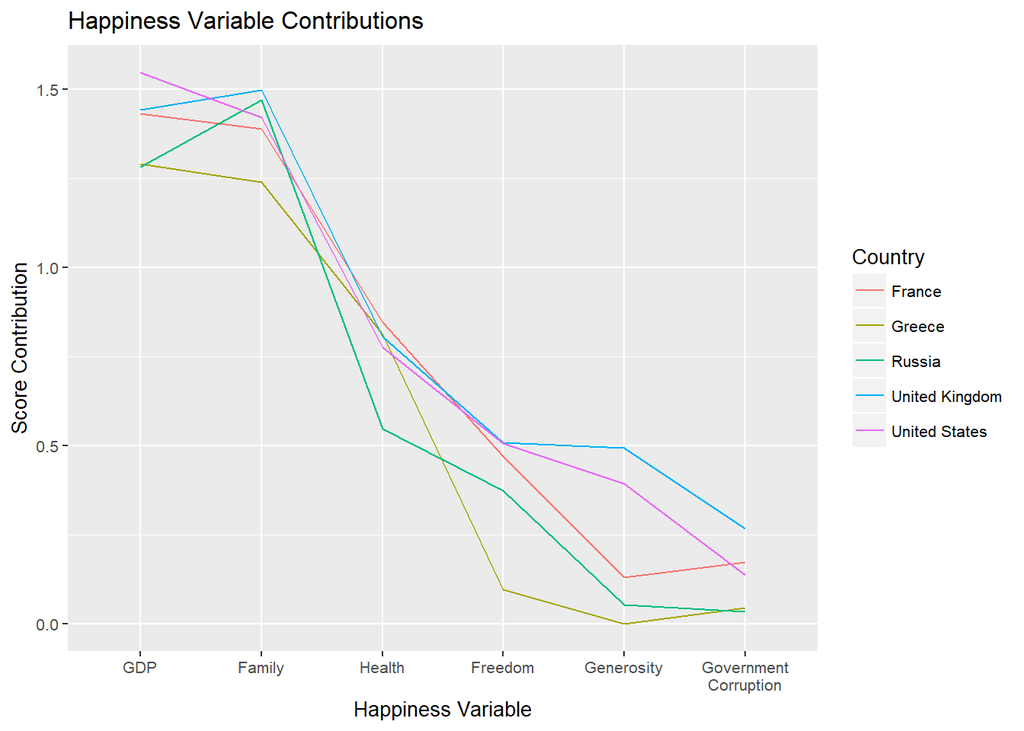

## Method

For each of the five countries examined I scraped the Wikipedia pages of 20-30 of its most prominent authors. I then scored the pages using the AFINN lexicon for its positive vs negative sentiment. I reasoned authors with more negative biographies, probably led unhappier lives. Conversely, those with more positive biographies led happier lives. I assigned each author a “Mean Bio Score”

I then used the R-Gutenberg package to score the major literary works of these authors using both the AFINN and NRC lexicons and assigned each author a âMean Book Scoreâ for the overall positivity/negativity of their body of work.

Finally, I joined the “Mean Bio Scores”, “Mean Book Scores” and “NRC Scores” on author into one large table. The table required some light regex cleaning to deal with the accents in some of the authors’ name.

The NRC lexicon was used to find the proportion of words used by each author corresponding to emotions like âjoyâ and âfearâ.

The AFINN lexicon was used since it applies a score to words ranging from -5 to 5. I found this lexicon more nuanced than the BING lexicon which simply categorizes words into 1 or -1 scores. For example, with BING, the phrase âtortured and exiledâ would receive the same negative score as âunhappy and sad childhoodâ which I didnât think was adequate.

Below is a snapshot of the final table produced.

```
## # A tibble: 123 x 12
##    author                country Mean_Bio_Score Mean_Book_Score anger.prop
##    <chr>                 <chr>            <dbl>           <dbl>      <dbl>
##  1 Fyodor Dostoevsky     Russia         -0.526         -0.353       0.122
##  2 Leo Tolstoy           Russia         -0.301          0.0490      0.112
##  3 Nikolai Gogol         Russia         -0.181         -0.00716     0.0980
##  4 Ivan Turgenev         Russia         -0.319         -0.0333      0.103
##  5 Anton Chekhov         Russia         -0.153         -0.246       0.111
##  6 Maxim Gorky           Russia         -0.285         -0.348       0.119
##  7 Yevgeny Zamyatin      Russia         -0.0238        NA          NA
##  8 Alexander Pushkin     Russia          0.282         -0.215       0.109
##  9 Aleksandr Solzhenits~ Russia         -0.823         NA          NA
## 10 Vladimir Nabokov      Russia          0.0417        NA          NA
## # ... with 113 more rows, and 7 more variables: anticipation.prop <dbl>,
## #   disgust.prop <dbl>, fear.prop <dbl>, joy.prop <dbl>,
## #   sadness.prop <dbl>, surprise.prop <dbl>, trust.prop <dbl>
```

## Literary Analysis

Now we can look at some plots and see if there are any relationships between the happiness of an author, and the overall sentiment of their work. We will also examine whether an author’s native country’s happiness is related to their own happiness, as well as the overall sentiment of their work.

Here I plotted the author’s happiness against the sentiment scores of their books. I was hoping to see a linear relationship, that happier authors write happier books. But for the most part, this does not seem to be the case, with a large cluster of the authors hovering around the 0 score on both book sentiment and biography sentiment.

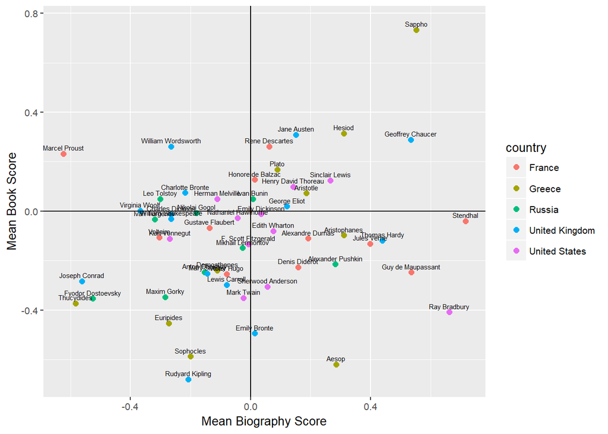

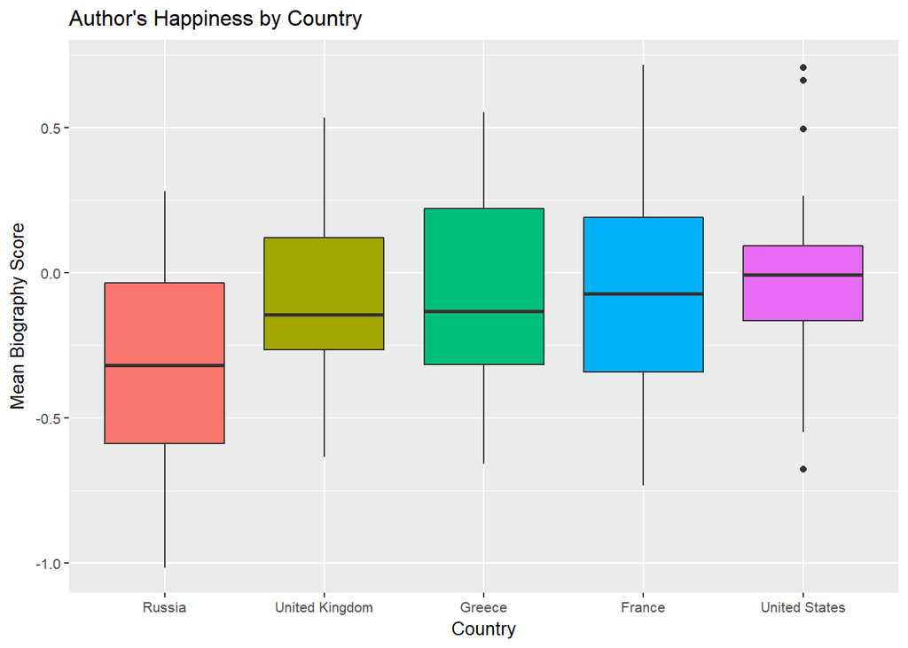

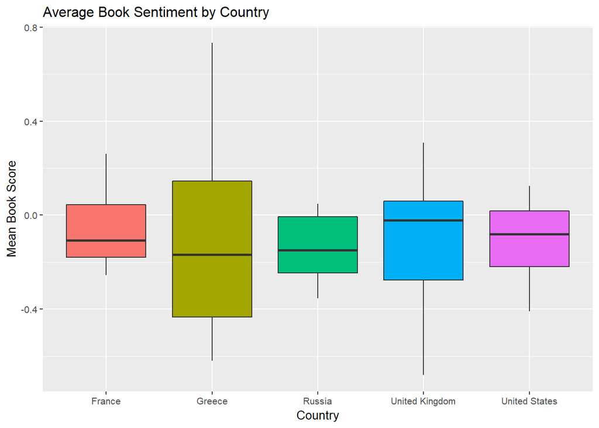

## NRC Analysis

Now I examine how each country and the authors from those countries differed in their use of NRC words like “joy”, “surprise”, “anger” etc. I had hoped for a pattern to emerge, like American authors used more “pride” word on average than other countries. However, what emerged was the fact that the proportion of NRC emotion words used by each country was about the same.

To perform these analyses, I had to gather the NRC variables in my authors_and_bios table in order to be able to plot them all together.

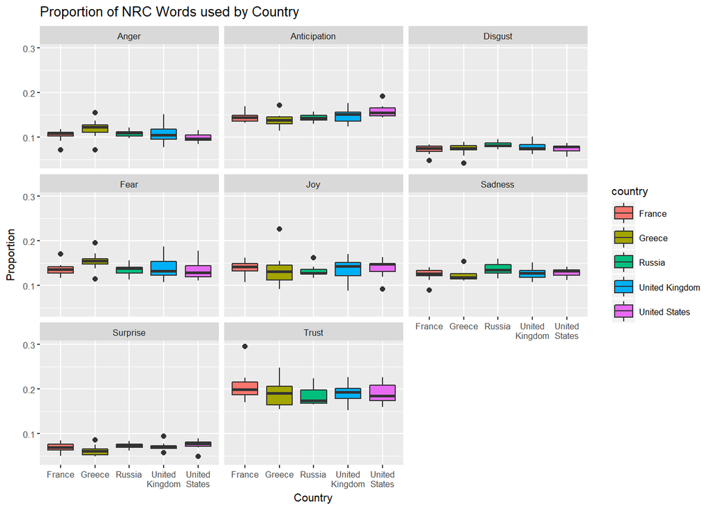

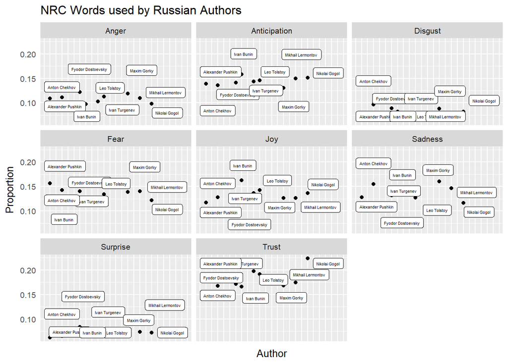

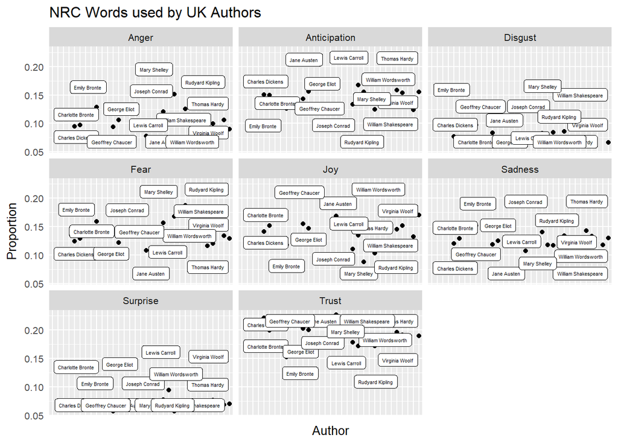

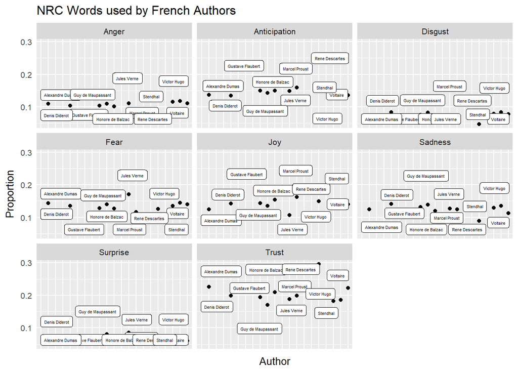

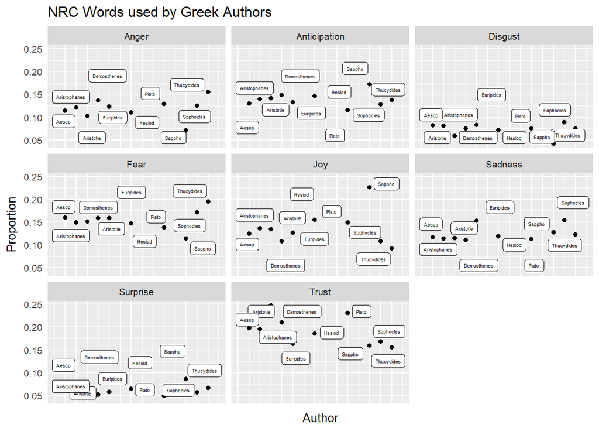

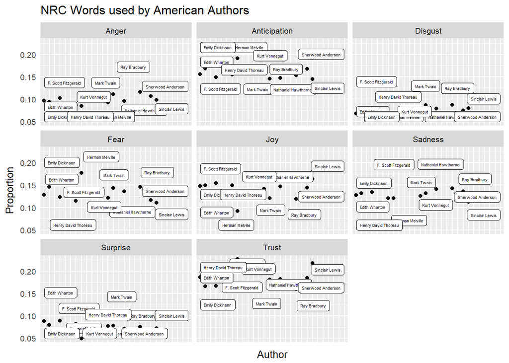